# Black FridayFinalCoding

```python
import pandas as pd
import numpy as np

from matplotlib import pyplot as plt
import seaborn as sb
```

```python
bf = pd.read_csv("Black_friday_train.csv")
bf.head()
```

|  | User_ID | Product_ID | Gender | Age | Occupation | City_Category | Stay_In_Current_City_Years | Marital_Status | Product_Category_1 | Product_Category_2 | Product_Category_3 | Purchase |
| --- | --- | --- | --- | --- | --- | --- | --- | --- | --- | --- | --- | --- |
| 0 | 1000001 | P00069042 | F | 0-17 | 10 | A | 2 | 0 | 3 | NaN | NaN | 8370 |
| 1 | 1000001 | P00248942 | F | 0-17 | 10 | A | 2 | 0 | 1 | 6.0 | 14.0 | 15200 |
| 2 | 1000001 | P00087842 | F | 0-17 | 10 | A | 2 | 0 | 12 | NaN | NaN | 1422 |
| 3 | 1000001 | P00085442 | F | 0-17 | 10 | A | 2 | 0 | 12 | 14.0 | NaN | 1057 |
| 4 | 1000002 | P00285442 | M | 55+ | 16 | C | 4+ | 0 | 8 | NaN | NaN | 7969 |

```python
bf['Gender'].value_counts()
```

```
M    414259
F    135809
Name: Gender, dtype: int64
```

```python
bf.shape
```

```
(550068, 12)
```

Variable Definition User_ID User ID Product_ID Product ID Gender Sex of User Age Age in bins Occupation Occupation (Masked) City_Category Category of the City (A,B,C) Stay_In_Current_City_Years Number of years stay in current city Marital_Status Marital Status Product_Category_1 Product Category (Masked) Product_Category_2 Product may belongs to other category also (Masked) Product_Category_3 Product may belongs to other category also (Masked) Purchase Purchase Amount (Target Variable)

```python
bf[['Purchase','Occupation']].describe()
```

|  | Purchase | Occupation |
| --- | --- | --- |
| count | 550068.000000 | 550068.000000 |
| mean | 9263.968713 | 8.076707 |
| std | 5023.065394 | 6.522660 |
| min | 12.000000 | 0.000000 |
| 25% | 5823.000000 | 2.000000 |
| 50% | 8047.000000 | 7.000000 |
| 75% | 12054.000000 | 14.000000 |
| max | 23961.000000 | 20.000000 |

```python
bf.info()
```

```
<class 'pandas.core.frame.DataFrame'>
RangeIndex: 550068 entries, 0 to 550067
Data columns (total 12 columns):
User_ID                       550068 non-null int64
Product_ID                    550068 non-null object
Gender                        550068 non-null object
Age                           550068 non-null object
Occupation                    550068 non-null int64
City_Category                 550068 non-null object
Stay_In_Current_City_Years    550068 non-null object
Marital_Status                550068 non-null int64
Product_Category_1            550068 non-null int64
Product_Category_2            376430 non-null float64
Product_Category_3            166821 non-null float64
Purchase                      550068 non-null int64
dtypes: float64(2), int64(5), object(5)
memory usage: 50.4+ MB
```

```python
bf.isna().sum()/len(bf)
```

```
User_ID                       0.000000
Product_ID                    0.000000
Gender                        0.000000
Age                           0.000000
Occupation                    0.000000
City_Category                 0.000000
Stay_In_Current_City_Years    0.000000
Marital_Status                0.000000
Product_Category_1            0.000000
Product_Category_2            0.315666
Product_Category_3            0.696727
Purchase                      0.000000
dtype: float64
```

## As 31% and 69% of values are missing it is ok to drop the columns

```python
bf.drop(['Product_Category_2','Product_Category_3'],axis =1,inplace = True)
```

## DROPPING USERID AND PRODUCT ID AS THEY ARE NOT RELEVENT FOR REGRESSION

```python
bf.drop(['User_ID','Product_ID'],axis =1,inplace = True)
```

```python
bf.info()
```

```
<class 'pandas.core.frame.DataFrame'>
RangeIndex: 550068 entries, 0 to 550067
Data columns (total 8 columns):
Gender                        550068 non-null object
Age                           550068 non-null object
Occupation                    550068 non-null int64
City_Category                 550068 non-null object
Stay_In_Current_City_Years    550068 non-null object
Marital_Status                550068 non-null int64
Product_Category_1            550068 non-null int64
Purchase                      550068 non-null int64
dtypes: int64(4), object(4)
memory usage: 33.6+ MB
```

```python
bf.head(3)
```

|  | Gender | Age | Occupation | City_Category | Stay_In_Current_City_Years | Marital_Status | Product_Category_1 | Purchase |
| --- | --- | --- | --- | --- | --- | --- | --- | --- |
| 0 | F | 0-17 | 10 | A | 2 | 0 | 3 | 8370 |
| 1 | F | 0-17 | 10 | A | 2 | 0 | 1 | 15200 |
| 2 | F | 0-17 | 10 | A | 2 | 0 | 12 | 1422 |

# SOME INSIGHTS Through EDA

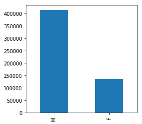

```python
plt.rcParams['figure.figsize'] = [4,4]
bf['Gender'].value_counts().plot(kind = 'bar')
```

- Insights from the graph
  - Male users are more than Female

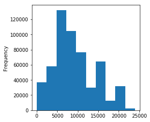

```python
bf['Purchase'].plot(kind = 'hist')
```

```python
bf['Stay_In_Current_City_Years'].value_counts()
```

```
1     193821
2     101838
3      95285
4+     84726
0      74398
Name: Stay_In_Current_City_Years, dtype: int64
```

```python
bf['Age'].value_counts()
```

```
26-35    219587
36-45    110013
18-25     99660
46-50     45701
51-55     38501
55+       21504
0-17      15102
Name: Age, dtype: int64
```

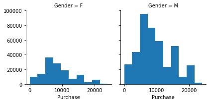

```python
sb.FacetGrid(bf,col = 'Gender').map(plt.hist,'Purchase')
```

- Insights from the graph
  - MORE PURCHASES HAPPENING FROM MALES

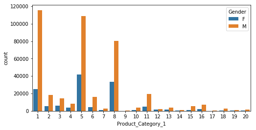

```python
plt.rcParams['figure.figsize'] = [8,4]
sb.countplot(bf['Product_Category_1'],hue=bf['Gender'])
```

- Insights from the graph
  - Product_category_1 1,5,8 were the most selling

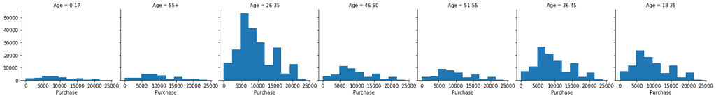

```python
plt.rcParams['figure.figsize'] = [10,10]
sb.FacetGrid(bf,col = 'Age').map(plt.hist,'Purchase')
```

- Insights from the graph
  - The age between 26-35 bin has made more purchases

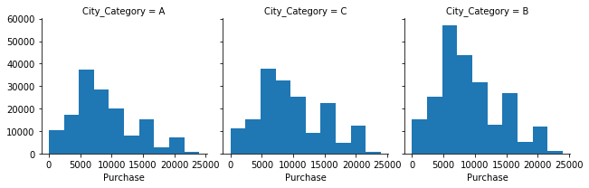

```python
plt.rcParams['figure.figsize'] = [10,10]
sb.FacetGrid(bf,col = 'City_Category').map(plt.hist,'Purchase')
```

- Insights from the graph
  - City category b has more purchases

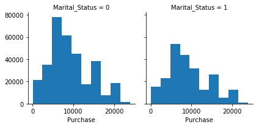

```python
sb.FacetGrid(bf,col = 'Marital_Status').map(plt.hist,'Purchase')
```

- Insights from the graph
  - Single shopped more than Married

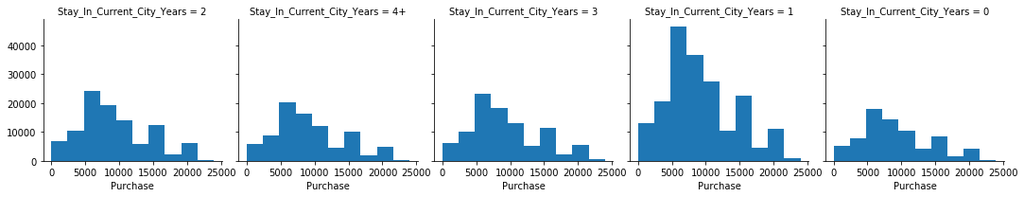

```python
sb.FacetGrid(bf,col = 'Stay_In_Current_City_Years').map(plt.hist,'Purchase')
```

- Insights from the graph are
  - Customers who has resided in their city for 1 year shopped the most

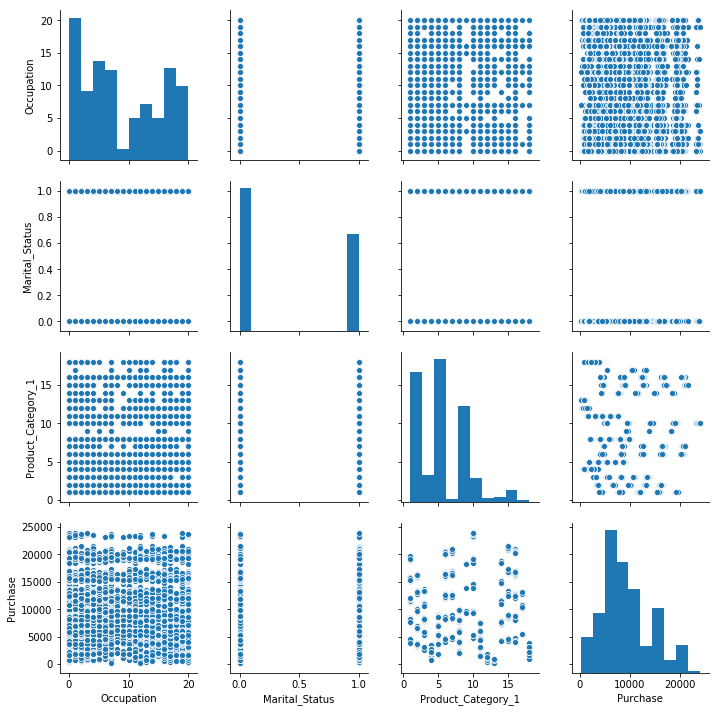

```python
import seaborn as sb

sb.pairplot(bf.iloc[0:10000,:])
```

##### No patters in the scatters against puchase

# DATA PREPERATION FOR CLUSTERING

```python
bf.head(2)
```

|  | Gender | Age | Occupation | City_Category | Stay_In_Current_City_Years | Marital_Status | Product_Category_1 | Purchase |
| --- | --- | --- | --- | --- | --- | --- | --- | --- |
| 0 | F | 0-17 | 10 | A | 2 | 0 | 3 | 8370 |
| 1 | F | 0-17 | 10 | A | 2 | 0 | 1 | 15200 |

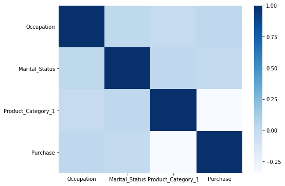

```python
plt.rcParams['figure.figsize'] = [8,6]
sb.heatmap(bf.corr(),cmap='Blues')
```

# Creation of DUMMIES

```python
bfd = pd.get_dummies(bf)
```

```python
bfd.head
```

[output not shown]

[output cut: 364 more lines]

```python
from sklearn.preprocessing import StandardScaler

ssc = StandardScaler()

bfd['Purchase'] = ssc.fit_transform(bfd[['Purchase']])

bfd.head(3)
```

|  | Occupation | Marital_Status | Product_Category_1 | Purchase | Gender_F | Gender_M | Age_0-17 | Age_18-25 | Age_26-35 | Age_36-45 | ... | Age_51-55 | Age_55+ | City_Category_A | City_Category_B | City_Category_C | Stay_In_Current_City_Years_0 | Stay_In_Current_City_Years_1 | Stay_In_Current_City_Years_2 | Stay_In_Current_City_Years_3 | Stay_In_Current_City_Years_4+ |
| --- | --- | --- | --- | --- | --- | --- | --- | --- | --- | --- | --- | --- | --- | --- | --- | --- | --- | --- | --- | --- | --- |
| 0 | 10 | 0 | 3 | -0.177973 | 1 | 0 | 1 | 0 | 0 | 0 | ... | 0 | 0 | 1 | 0 | 0 | 0 | 0 | 1 | 0 | 0 |
| 1 | 10 | 0 | 1 | 1.181756 | 1 | 0 | 1 | 0 | 0 | 0 | ... | 0 | 0 | 1 | 0 | 0 | 0 | 0 | 1 | 0 | 0 |
| 2 | 10 | 0 | 12 | -1.561193 | 1 | 0 | 1 | 0 | 0 | 0 | ... | 0 | 0 | 1 | 0 | 0 | 0 | 0 | 1 | 0 | 0 |

3 rows × 21 columns

```python
bfd.info()
```

```
<class 'pandas.core.frame.DataFrame'>
RangeIndex: 550068 entries, 0 to 550067
Data columns (total 21 columns):
Occupation                       550068 non-null int64
Marital_Status                   550068 non-null int64
Product_Category_1               550068 non-null int64
Purchase                         550068 non-null float64
Gender_F                         550068 non-null uint8
Gender_M                         550068 non-null uint8
Age_0-17                         550068 non-null uint8
Age_18-25                        550068 non-null uint8
Age_26-35                        550068 non-null uint8
Age_36-45                        550068 non-null uint8
Age_46-50                        550068 non-null uint8
Age_51-55                        550068 non-null uint8
Age_55+                          550068 non-null uint8
City_Category_A                  550068 non-null uint8
City_Category_B                  550068 non-null uint8
City_Category_C                  550068 non-null uint8
Stay_In_Current_City_Years_0     550068 non-null uint8
Stay_In_Current_City_Years_1     550068 non-null uint8
Stay_In_Current_City_Years_2     550068 non-null uint8
Stay_In_Current_City_Years_3     550068 non-null uint8
Stay_In_Current_City_Years_4+    550068 non-null uint8
dtypes: float64(1), int64(3), uint8(17)
memory usage: 25.7 MB
```

```python
from sklearn.cluster import KMeans
```

```python
km1 = KMeans(n_clusters=3)

km1.fit(bfd)
```

```
KMeans(algorithm='auto', copy_x=True, init='k-means++', max_iter=300,
    n_clusters=3, n_init=10, n_jobs=None, precompute_distances='auto',
    random_state=None, tol=0.0001, verbose=0)
```

```python
cluster_error = []

for i in range(1,6):
    km1 = KMeans(n_clusters= i , random_state= 3)
    km1.fit(bfd)
    cluster_error.append(km1.inertia_)                           ## DISTANCES FROM THE CENTROID
    print("for k : {0} error : {1}".format(i,cluster_error[i-1]))        ## CHECK FOR DRASTIC CHANGE
```

```
for k : 1 error : 34010794.75965335
for k : 2 error : 14961751.53078461
for k : 3 error : 11613795.693804031
for k : 4 error : 9507858.331875158
for k : 5 error : 8145719.141310868
```

```python
cluster_error
```

```
[34010794.75965335,
 14961751.53078461,
 11613795.693804031,
 9507858.331875158,
 8145719.141310868]
```

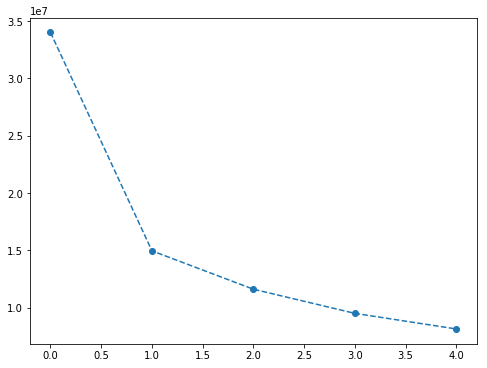

```python
plt.plot(cluster_error,'--o')
```